# Gradient boosting machines for modelling insurance data

Katrien Antonio, Roel Henckaerts

April 2019

# Goal of the demo

This demo illustrates the basic principles of fitting claim frequency data with a gradient boosting machine as implemented in the `gbm` package. The code is based on lecture sheets developed by prof. Julien Trufin on ‘Machine learning techniques in non-life insurance ratemaking’ and on the lecture notes by prof. Mario Wüthrich on ‘Data analytics for non-life insurance pricing’. A detailed use case on modelling claim frequency as well as severity data with gbms is documented in the paper https://arxiv.org/abs/1904.10890 by Roel Henckaerts, Katrien Antonio, Marie-Pier Côté (Université de Laval, Canada) and Roel Verbelen.

In this demo you focus on fitting gradient boosting machines with the R package `gbm`. This package is an implementation of extensions to Freund and Schapire’s AdaBoost algorithm and Friedman’s gradient boosting machine. It includes regression methods for least squares, absolute loss, t-distribution loss, quantile regression, logistic, multinomial logistic, Poisson, Cox proportional hazards partial likelihood, AdaBoost exponential loss, Huberized hinge loss, and Learning to Rank measures (LambdaMart). The package was originally developed by Greg Ridgeway.

With a focus on insurance pricing the Poisson deviance loss function is relevant for modeling frequency data (available in `gbm`). For modelling severities we typically use the gamma deviance as loss function. The latter is not available in the `gbm` package on CRAN, but it is available in the `gbm` package maintained on the GitHub page of Harry Southworth.

Make sure to install and to load the package before actually using it. We start with the `gbm` package available on CRAN.

```r
# remove.packages('gbm')
# install.packages("gbm")
library(gbm)
```

# Basic concepts illustrated on simulated data

## Generating the data

You simulate a data set of claim frequencies to illustrate the basic instructions. To replicate the results of the demo, you first specify a `seed`.

```r
set.seed(1)
```

In `R` the instruction `set.seed()` is the recommended way to specify seeds. This sets the seed of `R`’s random number generator, which is useful for creating simulations or random objects that can be reproduced.

You generate a data set of size `n`, in this case: 1000 records are generated.

```r
n <- 1000 # number of observations
```

Covariates in the artificial data set are: `Gender`, `Age`, `Split` and `Sport`. You generate their values as follows:

```r
Gender <- factor(sample(c("m", "f"), n, replace=TRUE))
Age <- sample(c(18:65), n, replace=TRUE)
Split <- factor(sample(c("yes", "no"), n, replace = TRUE))
Sport <- factor(sample(c("yes", "no"), n, replace = TRUE))
```

You will work with the following Poisson regression model
$$\begin{eqnarray*}
N_i &\sim& \text{POI}(\lambda_i) \\
\lambda_i &=& \exp{(\boldsymbol{x}_i^{'} \cdot \boldsymbol{\beta})}
\end{eqnarray*}$$
and let the mean of the Poisson distribution depend on the covariates in the following way.

```r
lambda <- 0.1*ifelse(Gender == "m", 1.5, 1)
lambda <- lambda*ifelse(Age >= 18 & Age < 30, 3, 1)
lambda <- lambda*ifelse(Age >= 30 & Age < 45, 2, 1)
lambda <- lambda*ifelse(Sport == "yes", 2.5, 1)
```

Thus, the expected claim frequency depends on `Age`, `Gender` and `Sport`, but not on `Split`. As a final step in generating the data, you randomly pick observations from a Poisson distribution with the specified vector `lambda` as the mean. You store the resulting, artificial data set in the object `data`.

```r
N <- rpois(n, lambda)
data <- data.frame(N, Gender, Age, Sport, Split)
```

You can inspect the first rows of this dataframe with the `head` function.

```r
head(data, n = 10)
```

```
##    N Gender Age Sport Split
## 1  0      m  43    no    no
## 2  0      m  50   yes    no
## 3  0      f  36   yes    no
## 4  0      f  63   yes   yes
## 5  2      m  23    no   yes
## 6  0      f  19    no   yes
## 7  1      f  42   yes    no
## 8  0      f  45   yes   yes
## 9  0      f  58    no    no
## 10 0      m  49    no   yes
```

## Algorithmic essentials when fitting a gbm

The simulated data can be used to fit a gbm, where the goal is to explain the number of claims `N` using the predictors `Age`, `Gender`, `Sport` and `Split`. Boosting is an iterative statistical method that combines many weak learners into one powerful predictor. Friedman (2001) introduced decision trees as weak learners; each tree improves the current model fit, thereby using information from previously grown trees. At each iteration, the pseudo-residuals are used to assess the regions of the predictor space for which the model performs poorly. The fit is then improved in a direction of better overall performance. The pseudo-residual $\rho_{i,t}$ for observation $i$ in iteration $t$ is calculated as the negative gradient of the loss function $-\partial \mathscr{L}\{y_i,f(\boldsymbol{x}_i)\} / \partial f(\boldsymbol{x}_i)$, evaluated at the current model fit. Hence, the name gradient boosting machine (`gbm`). The boosting method learns slowly by fitting a small tree of depth $d$ to these pseudo-residuals, improving the model fit in areas where it does not perform well. For each region $R_j$ of that tree, the update $\hat{b}_j$ is calculated as the constant that has to be added to the previous model fit to minimize the loss function, namely $b$ that minimizes $\mathscr{L}\{y_i,f(\boldsymbol{x}_i)+b\}$ over this region. A shrinkage parameter $\lambda$ controls the learning speed by shrinking updates as follows: $f_{new}(\boldsymbol{x}) = f_{old}(\boldsymbol{x}) + \lambda \cdot update$. A lower $\lambda$ usually results in better performance but also increases computation time because more trees are needed to converge to a good solution. The collection of trees at the final iteration $T$ is used to make predictions. Algorithm 2 in https://arxiv.org/abs/1904.10890 is a sketch of the essential steps in the fitting procedure.

The `gbm` function allows a lot of tuning parameters in its specification. A detailed explanation can be found here: https://www.rdocumentation.org/packages/gbm/versions/2.1.4/topics/gbm. The most important tuning parameters are the following ones:

- `n.trees`: the number of trees used in the ensemble, denoted with $T$ in the Henckaerts et al. (2019) paper
- `interaction.depth`: the depth of each of the trees used in the ensemble, denoted $d$ in the Henckaerts et al. (2019) paper.

These tuning parameters are discussed in detail in https://arxiv.org/abs/1904.10890 by Roel Henckaerts, Katrien Antonio, Marie-Pier Côté (Université de Laval, Canada) and Roel Verbelen.

Next to these tuning parameters you will also have to fix some hyperparameters, e.g.:

- `shrinkage`: the shrinkage or learning rate which controls the learning speed by shrinking updates, $\lambda$ in the Henckaerts et al. (2019) paper
- `bag.fraction`: the subsampling fraction leading to stochastic gradient boosting, introduced by Friedman (2002). This injects randomness in the training process by subsampling the data at random without replacement in each iteration. In each iteration, the model update is computed from a randomly selected subsample of size `bag.fraction` times the number of observations in the training data set. This `bag.fraction` is denoted as $\delta$ in Henckaerts et al. (2019).

Naturally, you will also have to make a meaningful choice for the distribution of the respons variable: * `distribution`: the distribution assumed for the response variable.

The basic function call in `gbm` then goes as follows:

```r
set.seed(3)
gbm_sim <- gbm(N ~ Gender + Age + Split + Sport, # formula
               data = data, # data set
               var.monotone = c(0,0,0,0), # -1: monotone decrease, +1: monotone   increase, 0: no monotone restrictions
               distribution = "poisson", # see the help for other choices
               n.trees = 250, # number of trees
               shrinkage = 0.05, # shrinkage or learning rate
               interaction.depth = 3, # 1: additive model, 2: two-way interactions, etc.
               bag.fraction = 0.5, # subsampling fraction
               train.fraction = 1, # fraction of data for training
               n.minobsinnode = 10, # minimum total weight needed in each node
               cv.folds = 3, # do 3-fold cross-validation
               keep.data = TRUE, # keep a copy of the dataset with the object
               verbose = FALSE, # don’t print out progress
               n.cores = 1) # use only a single core
```

## A first exploration

A `print` of the fitted gbm object gives you an overview of the fitted model and its main characteristics (e.g. loss function used, number of iterations, best iteration)

```r
print(gbm_sim)
```

```
## gbm(formula = N ~ Gender + Age + Split + Sport, distribution = "poisson",
##     data = data, var.monotone = c(0, 0, 0, 0), n.trees = 250,
##     interaction.depth = 3, n.minobsinnode = 10, shrinkage = 0.05,
##     bag.fraction = 0.5, train.fraction = 1, cv.folds = 3, keep.data = TRUE,
##     verbose = FALSE, n.cores = 1)
## A gradient boosted model with poisson loss function.
## 250 iterations were performed.
## The best cross-validation iteration was 60.
## There were 4 predictors of which 4 had non-zero influence.
```

A `summary` call on the fitted gbm object `gbm_sim` returns the importance of each of the covariates used in the model. For a covariate $x_{\ell}$ in the set of available covariates $\{1,\ldots, p\}$ the importance of a specific feature $x_{\ell}$ in a tree $t$ is measured by summing the improvements in the loss function over all splits on $x_{\ell}$

$$\begin{eqnarray*}
\mathcal{I}_{\ell}(t) &=& \sum_{j=1}^{J-1} \mathbb{I}\{v(j)= \ell\}(\Delta \mathcal{L})_j.
\end{eqnarray*}$$

We often normalize these variable importance values such that they sum to 100%, giving a clear idea about the relative contribution of each variable.

For an ensemble of trees we average the importance of variable $x_{\ell}$ over the different trees that compose the ensemble

$$\begin{eqnarray*}
\mathcal{I}_{\ell} &=& \frac{1}{T}\sum_{t=1}^{T} \mathcal{I}_{\ell}(t).
\end{eqnarray*}$$

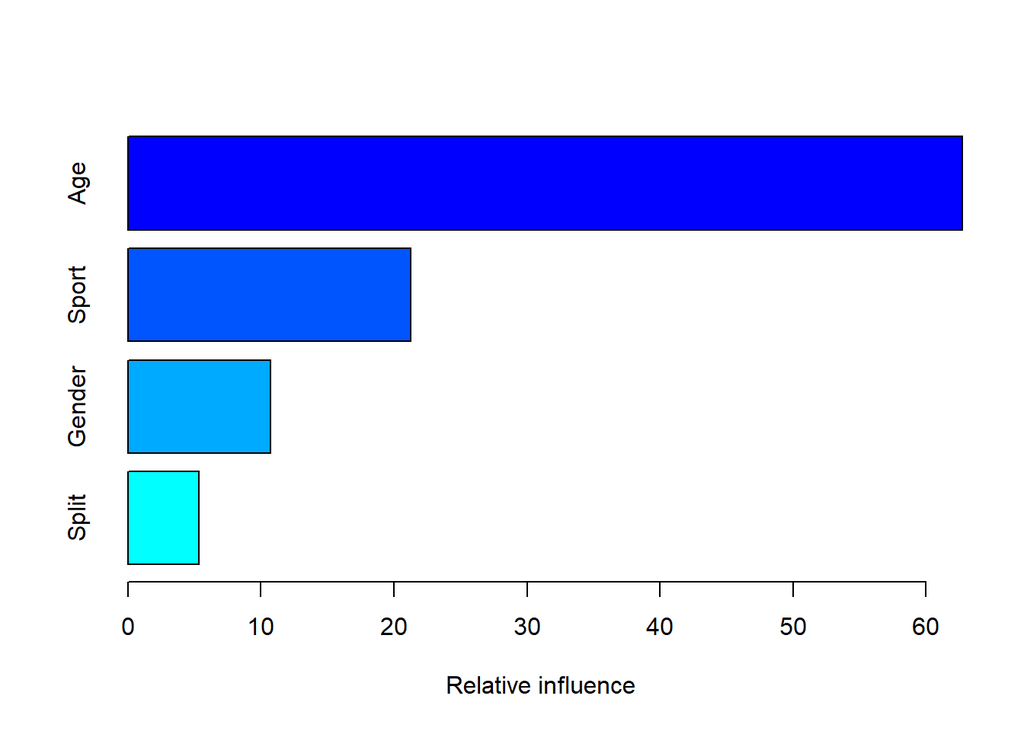

```
##           var   rel.inf
## Age       Age 62.715966
## Sport   Sport 21.250534
## Gender Gender 10.727721
## Split   Split  5.305779
```

```r
summary(gbm_sim)
```

Note that these `rel.inf` sum to 100:

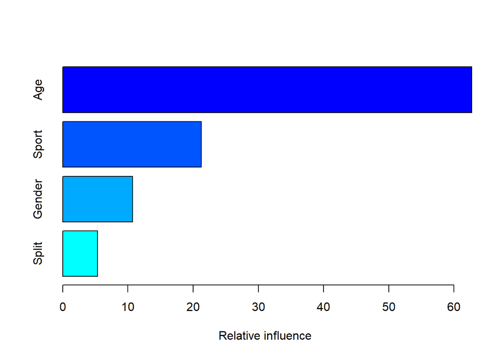

```
## [1] 100
```

```r
sum(summary(gbm_sim)$rel.inf)
```

The variable `Age` is most informative when modelling the number of claims, followed by `Sport` and `Gender`. The explanatory power of `Split` is weak, as expected.

The `gbm` uses a log link and the exposure is treated properly (shown later on). The argument `initF` is the initial predicted value to which trees make adjustments (on the log scale), and here it is

```r
gbm_sim$initF
```

```
## [1] -0.8603831
```

```r
exp(gbm_sim$initF)
```

```
## [1] 0.423
```

```r
sum(data$N)/n
```

```
## [1] 0.423
```

The deviance computed here is twice the negative loglikelihood (up to a constant)
$$-2\times\frac{1}{n}\sum_{i=1}^n y_i \{f(x_i)+\log(d_i)\}-\exp\{f(x_i)+\log(d_i)\},$$
which is proportional to the deviance but does not include the saturated model loglikelihood. As this is just a constant, results are equivalent. The training deviance can be plotted against the number of boosted trees as follows. As expected, training deviance decreases when increasing the number of trees, and overfitting results.

```r
gbm_sim$train.error[250]
```

```
## [1] 1.307329
```

```r
-2*mean(data$N*(gbm_sim$fit+log(1))-exp(gbm_sim$fit+log(1)))
```

```
## [1] 1.307329
```

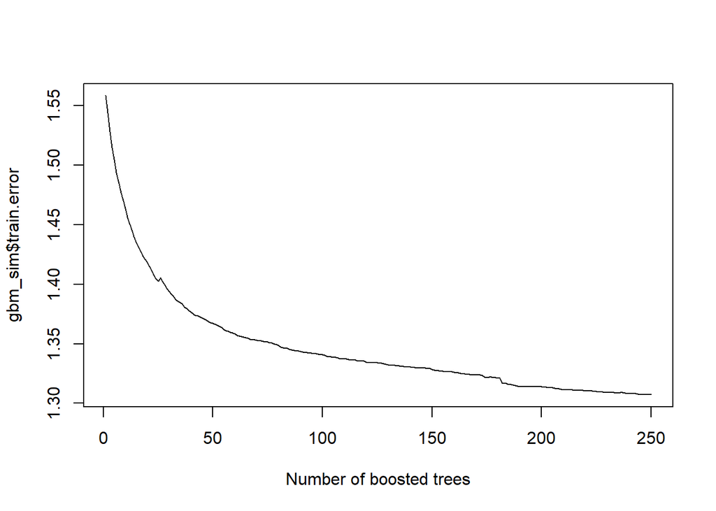

```r
plot(gbm_sim$train.error, type = "l", xlab = "Number of boosted trees")
```

It is also possible to inspect the trees constructed in the `gbm` fitting process. You can extract these with the function `pretty.gbm.tree`. In what follows, `SplitVar = -1` indicates a terminal node, the other variables are numbered from 0 to 3 according to the order `Gender + Age + Split + Sport` used in the `gbm` function call. `LeftNode` gives the index of the row (in the printed output) corresponding to the left node, similar for `RightNode`. Below, the first tree constructed by the `gbm` first splits on `Sport`, followed by a split on `Age` (at split point 44.5) and a split on `Gender`. Recall that we specified the `interaction.depth` equal to 3 in the `gbm` call. The second tree in the ensemble splits on `Sport` and `Age`, the final tree in the ensemble only splits on `Age`.

```r
pretty.gbm.tree(gbm_sim, i.tree = 1)
```

```
##   SplitVar SplitCodePred LeftNode RightNode MissingNode ErrorReduction
## 0        3   0.000000000        1         2           9      23.703120
## 1       -1  -0.033804290       -1        -1          -1       0.000000
## 2        1  44.500000000        3         7           8      15.132568
## 3        0   1.000000000        4         5           6       5.336508
## 4       -1   0.020181235       -1        -1          -1       0.000000
## 5       -1   0.044195680       -1        -1          -1       0.000000
## 6       -1   0.034189661       -1        -1          -1       0.000000
## 7       -1  -0.007799555       -1        -1          -1       0.000000
## 8       -1   0.016483365       -1        -1          -1       0.000000
## 9       -1  -0.008761037       -1        -1          -1       0.000000
##   Weight   Prediction
## 0    500 -0.008761037
## 1    251 -0.033804290
## 2    249  0.016483365
## 3    144  0.034189661
## 4     60  0.020181235
## 5     84  0.044195680
## 6    144  0.034189661
## 7    105 -0.007799555
## 8    249  0.016483365
## 9    500 -0.008761037
```

```r
pretty.gbm.tree(gbm_sim, i.tree = 2)
```

```
##   SplitVar SplitCodePred LeftNode RightNode MissingNode ErrorReduction
## 0        3   2.000000000        1         2           9      21.597144
## 1       -1  -0.041053802       -1        -1          -1       0.000000
## 2        1  32.500000000        3         7           8      11.712074
## 3        1  23.500000000        4         5           6       2.716581
## 4       -1   0.048031267       -1        -1          -1       0.000000
## 5       -1   0.028887099       -1        -1          -1       0.000000
## 6       -1   0.036769992       -1        -1          -1       0.000000
## 7       -1   0.004468275       -1        -1          -1       0.000000
## 8       -1   0.014987991       -1        -1          -1       0.000000
## 9       -1  -0.011799986       -1        -1          -1       0.000000
##   Weight   Prediction
## 0    500 -0.011799986
## 1    239 -0.041053802
## 2    261  0.014987991
## 3     85  0.036769992
## 4     35  0.048031267
## 5     50  0.028887099
## 6     85  0.036769992
## 7    176  0.004468275
## 8    261  0.014987991
## 9    500 -0.011799986
```

```r
pretty.gbm.tree(gbm_sim, i.tree = 250)
```

```
##   SplitVar SplitCodePred LeftNode RightNode MissingNode ErrorReduction
## 0        1  44.500000000        1         8           9       1.287899
## 1        1  20.500000000        2         3           7       1.234244
## 2       -1   0.008278698       -1        -1          -1       0.000000
## 3        1  22.500000000        4         5           6       1.038854
## 4       -1  -0.021624781       -1        -1          -1       0.000000
## 5       -1  -0.007644604       -1        -1          -1       0.000000
## 6       -1  -0.009079831       -1        -1          -1       0.000000
## 7       -1  -0.007092659       -1        -1          -1       0.000000
## 8       -1   0.006117378       -1        -1          -1       0.000000
## 9       -1  -0.001729384       -1        -1          -1       0.000000
##   Weight   Prediction
## 0    500 -0.001729384
## 1    297 -0.007092659
## 2     34  0.008278698
## 3    263 -0.009079831
## 4     27 -0.021624781
## 5    236 -0.007644604
## 6    263 -0.009079831
## 7    297 -0.007092659
## 8    203  0.006117378
## 9    500 -0.001729384
```

## Optimal number of trees

It is very unlikely that our random guess of `n.trees` equals 250 is indeed the optimal value for the number of boosting iterations in the gbm. There are multiple ways of tuning the number of trees when using the `gbm` package.

A first approach uses the **out-of-bag (OOB)** error estimate. The out-of-bag (OOB) error is a way to measure the prediction error of machine learning models utilizing bootstrap aggregating (bagging) to sub-sample data samples used for training. We can predict each observation $i$ using each of the trees in which that observation was out-of-bag. In order to obtain a single prediction for the $i$th observation, we can average these predicted responses (if regression is the goal). An OOB prediction can be obtained in this way for each of the $n$ observations, from which the overall OOB MSE (for a regression problem) can be computed. The resulting OOB error is a valid estimate of the test error for the bagged model, since the response for each observation is predicted using only the trees that were not fit using that observation.

```r
best.iter.oob <- gbm.perf(gbm_sim, method = "OOB")
```

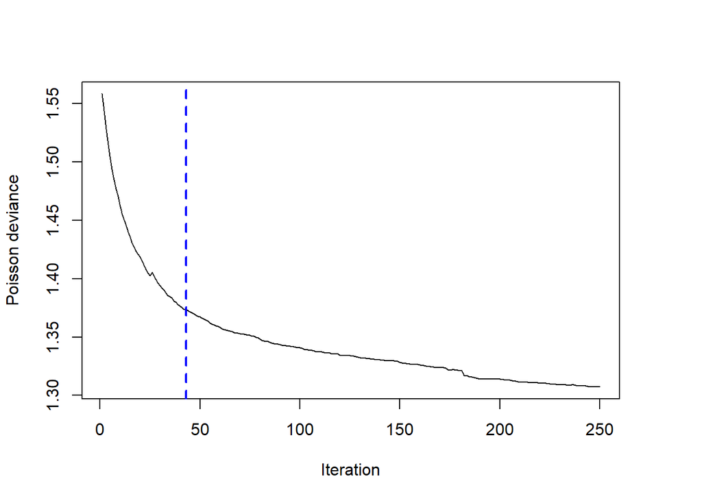

```r
print(best.iter.oob)
```

```
## [1] 43
```

A second approach uses the **heldout test set**. To use this option you should put the `train.fraction` to a value less than 1. For example

```r
gbm_sim <- gbm(N ~ Gender + Age + Split + Sport, # formula
               data = data, # data set
               var.monotone = c(0,0,0,0), # -1: monotone decrease, +1: monotone   increase, 0: no monotone restrictions
               distribution = "poisson", # see the help for other choices
               n.trees = 250, # number of trees
               shrinkage = 0.05, # shrinkage or learning rate
               interaction.depth = 3, # 1: additive model, 2: two-way interactions, etc.
               bag.fraction = 0.5, # subsampling fraction
               train.fraction = 0.5, # fraction of data for training
               n.minobsinnode = 10, # minimum total weight needed in each node
               cv.folds = 3, # do 3-fold cross-validation
               keep.data = TRUE, # keep a copy of the dataset with the object
               verbose = FALSE, # don’t print out progress
               n.cores = 1) # use only a single core
```

The train error is shown in black and the test error in red.

```r
best.iter.test <- gbm.perf(gbm_sim, method = "test")
```

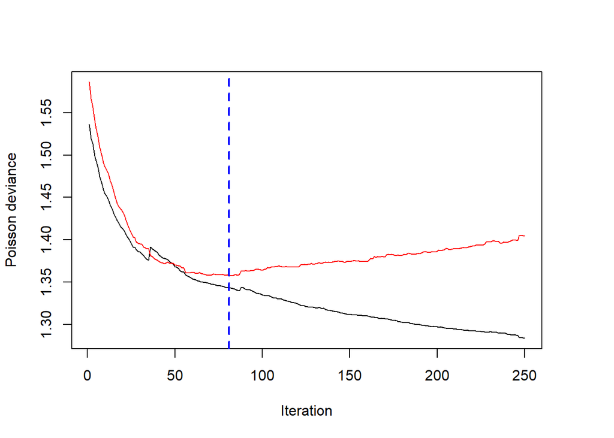

```r
print(best.iter.test)
```

```
## [1] 81
```

The graph shows the train error in black and the test error in red, with the optimal number of boosting iterations equal to `best.iter.test`.

A third approach performs **cross-validation** to find the optimal number of boosting iterations.

```r
best.iter.cv <- gbm.perf(gbm_sim, method = "cv")
```

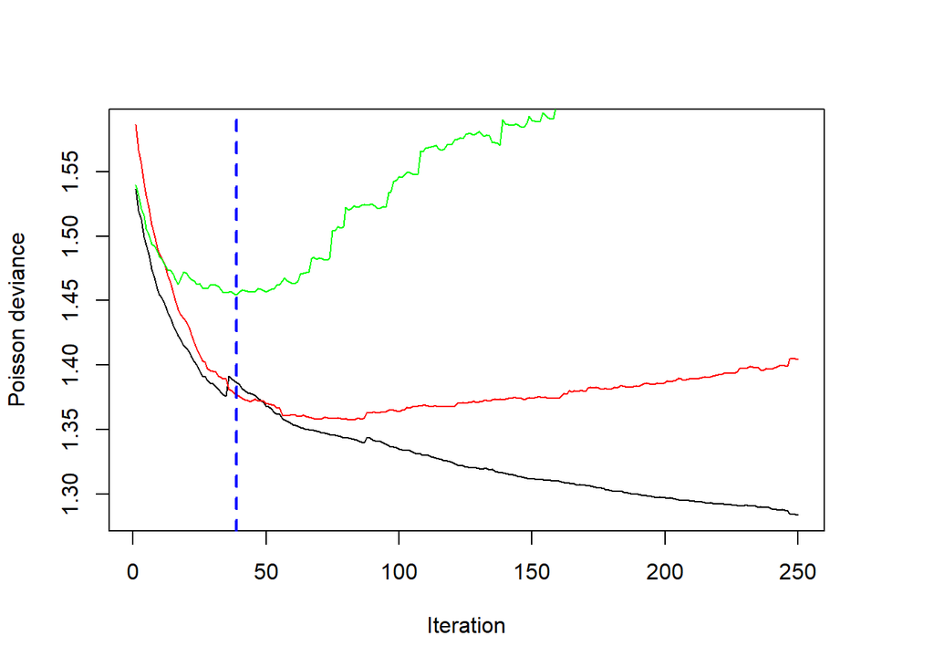

```r
print(best.iter.cv)
```

```
## [1] 39
```

The graph shows the train error in black, the validation error in green and the test error in red, with the optimal number of boosting iterations equal to `best.iter.cv`.

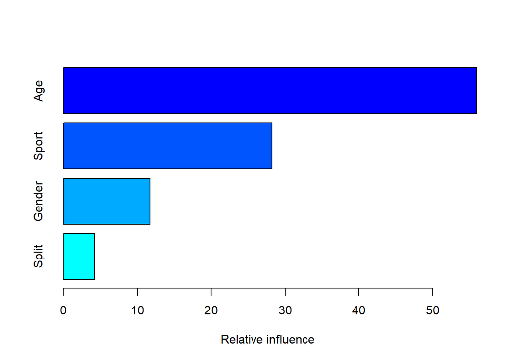

```
##           var   rel.inf
## Age       Age 55.899848
## Sport   Sport 28.225274
## Gender Gender 11.676116
## Split   Split  4.198762
```

```r
summary(gbm_sim, n.trees = best.iter.cv)
```

## Partial dependence plots

In addition to the importance of each variable it is relevant to understand the effect that each variable has on the claim frequency. In order to do so we can create **partial dependence plots** showing the marginal effect of each variable on the claim frequency. Hereto, we evaluate the prediction function in specific values of the variable of interest $x_{\ell}$, while averaging over a range of values of the other variables $\boldsymbol{x}^{\star}$:
$$\bar{f}_{\ell}(x_{\ell}) = \frac{1}{n}\sum_{i=1}^n f_{\text{model}}(x_{\ell}, \boldsymbol{x}_i^{\star}).$$

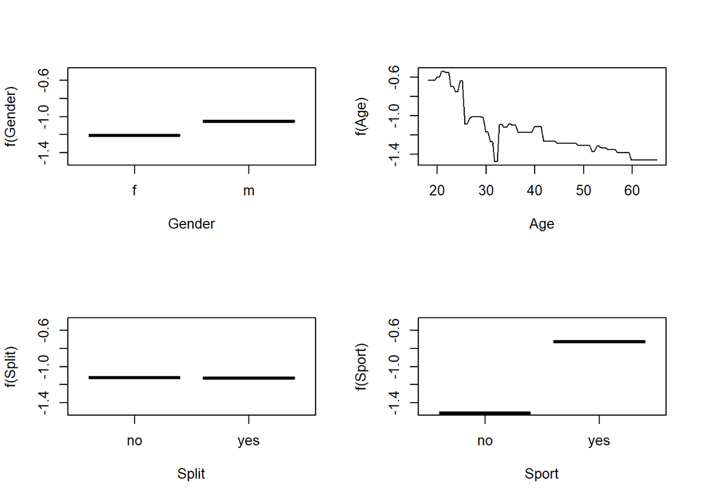

```r
par(mfrow = c(2,2))
plot(gbm_sim, 1, best.iter.cv, ylim=c(-1.5,-0.5))
plot(gbm_sim, 2, best.iter.cv, ylim=c(-1.5,-0.5))
plot(gbm_sim, 3, best.iter.cv, ylim=c(-1.5,-0.5))
plot(gbm_sim, 4, best.iter.cv, ylim=c(-1.5,-0.5))
```

These plots clearly indicate that driving a sports car, being younger and being male increases the likelihood of a claim. Note thate the plots created by the `gbm` package are at the level of the predictor, and not at the level of the response.

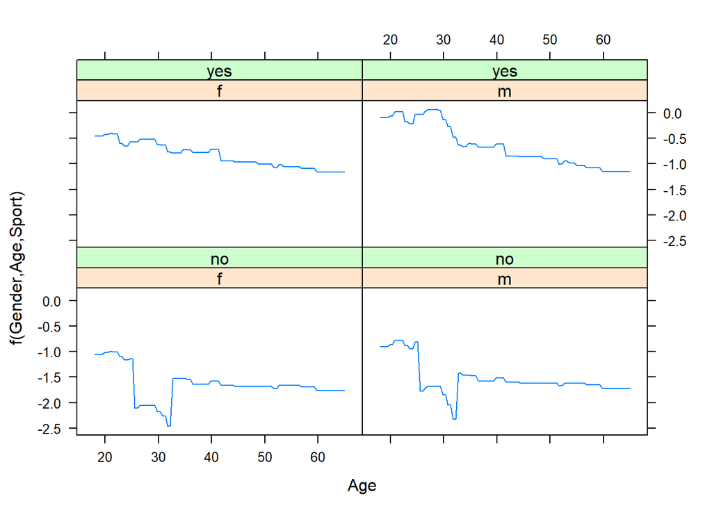

```r
par(mfrow = c(1,1))
plot(gbm_sim, c(1,2,4), best.iter.cv)
```

The package `pdp` allows to draw more fancy partial dependence plots. For example,

```r
#install.packages("pdp")
library(pdp)
pd <- partial(gbm_sim, n.trees = best.iter.cv, pred.var = c("Age"))
age_pdp <- plotPartial(pd)
```

## Individual conditional expectation plots

Individual conditional expectation plots (ICE plots) are also possible within the ``pdp` package. These show the effect of a variable on the predictions obtained from a model, but at the level of an individual observation $i$. We evaluate the prediction function in specific values of the variable of interest $x_{\ell}$, while the values of the other variables $\boldsymbol{x}^{\star}$ are kept fixed
$$\tilde{f}_{\ell,i}(x_{\ell}) = f_{\text{model}}(x_{\ell},\ \boldsymbol{x}_i^{\star})$$
where $\boldsymbol{x}_i^{\star}$ are the realized values of the other variables for observation $i$. We obtain an effect for each observation $i$, allowing us to detect interaction effects when some observations show different behavior compared to others. Individual conditional expectations can also be used to investigate the uncertainty of the effect of variable $x_{\ell}$ on the prediction outcome.

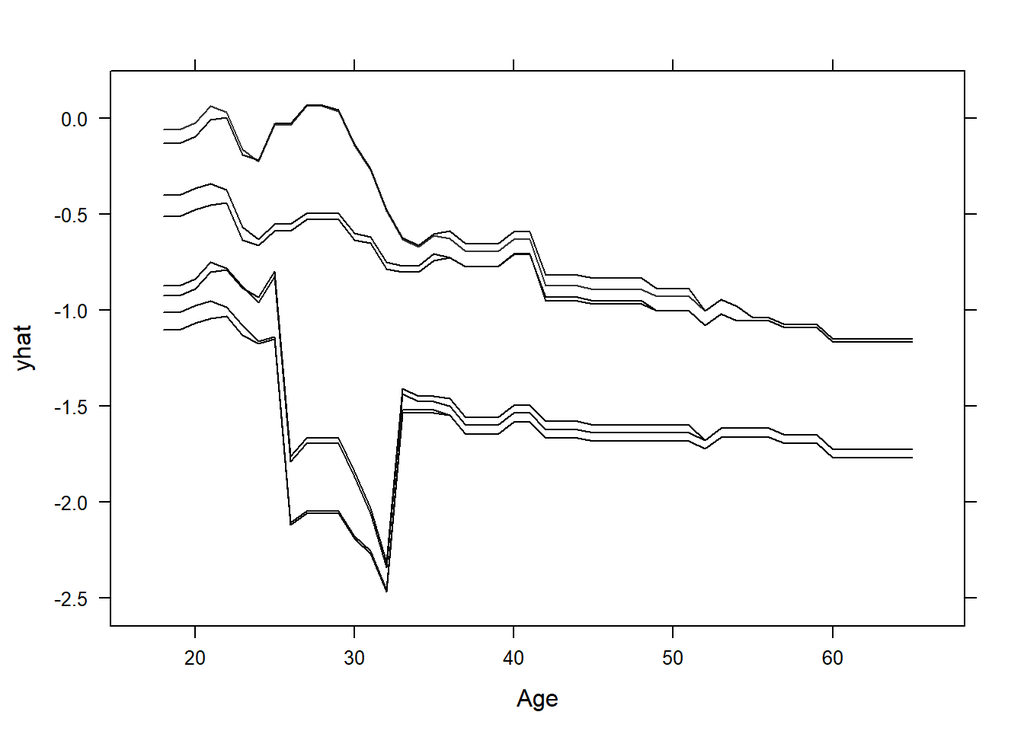

```r
set.seed(8711)
age_ice <- partial(gbm_sim, n.trees = best.iter.cv, pred.var = "Age", ice = TRUE)
plotPartial(age_ice[age_ice$yhat.id%in%sample(unique(age_ice$yhat.id), 100),], plot.pdp = FALSE, alpha = 0.2)
```

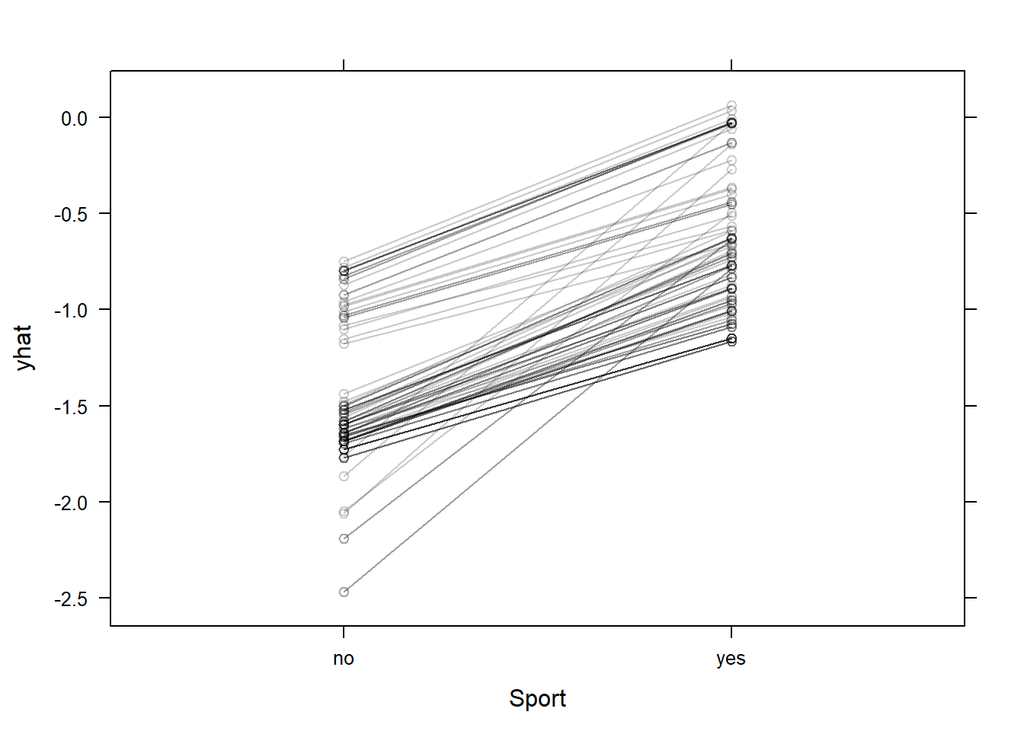

```r
sport_ice <- partial(gbm_sim, n.trees = best.iter.cv, pred.var = "Sport", ice = TRUE)
plotPartial(sport_ice[sport_ice$yhat.id%in%sample(unique(sport_ice$yhat.id), 100),], plot.pdp = FALSE, alpha = 0.2)
```

## Predictions from a fitted model

Once you are happy with your final model, you will use it to create predictions.

```r
lambda_hat <- predict(gbm_sim, data, n.trees = best.iter.cv, type = 'response')
data$lambda_hat <- lambda_hat
head(data, n = 10)
```

```
##    N Gender Age Sport Split lambda_hat
## 1  0      m  43    no    no  0.1976178
## 2  0      m  50   yes    no  0.3951903
## 3  0      f  36   yes    no  0.4842481
## 4  0      f  63   yes   yes  0.3116993
## 5  2      m  23    no   yes  0.4121281
## 6  0      f  19    no   yes  0.3321847
## 7  1      f  42   yes    no  0.3862003
## 8  0      f  45   yes   yes  0.3858811
## 9  0      f  58    no    no  0.1833989
## 10 0      m  49    no   yes  0.2021783
```

# Fitting the MTPL data set

Now it is your turn to grow a `gbm` ensemble for the MTPL data set that was used earlier in the course.

Start by loading the data.

```r
path <- file.path('C:/Users/u0043788/Dropbox/IIR Machine learning en Data Science opleiding/R demos/Gradient boosting')
path.MTPL <- file.path(path, "P&Cdata.txt")
data <- read.table(path.MTPL, header = TRUE)
data <- as.data.frame(data)
head(data)
```

```
##   ID NCLAIMS    AMOUNT       AVG        EXP COVERAGE     FUEL     USE
## 1  1       1 1618.0010 1618.0010 1.00000000      TPL gasoline private
## 2  2       0    0.0000        NA 1.00000000       PO gasoline private
## 3  3       0    0.0000        NA 1.00000000      TPL   diesel private
## 4  4       0    0.0000        NA 1.00000000      TPL gasoline private
## 5  5       1  155.9746  155.9746 0.04657534      TPL gasoline private
## 6  6       0    0.0000        NA 1.00000000      TPL gasoline private
##   FLEET    SEX AGEPH BM AGEC POWER   PC    TOWN     LONG      LAT
## 1     N   male    50  5   12    77 1000 BRUSSEL 4.355223 50.84539
## 2     N female    64  5    3    66 1000 BRUSSEL 4.355223 50.84539
## 3     N   male    60  0   10    70 1000 BRUSSEL 4.355223 50.84539
## 4     N   male    77  0   15    57 1000 BRUSSEL 4.355223 50.84539
## 5     N female    28  9    7    70 1000 BRUSSEL 4.355223 50.84539
## 6     N   male    26 11   12    70 1000 BRUSSEL 4.355223 50.84539
```

As a first step you fit a `gbm` for claim frequency using a selection of the available covariates. The `gbm` package available on CRAN has some difficulties with columns in the data set that are not used in the analysis. Therefore we first select the relevant columns

```r
str(data)
```

```
## 'data.frame':    163231 obs. of  18 variables:
##  $ ID      : int  1 2 3 4 5 6 7 8 9 10 ...
##  $ NCLAIMS : int  1 0 0 0 1 0 1 0 0 0 ...
##  $ AMOUNT  : num  1618 0 0 0 156 ...
##  $ AVG     : num  1618 NA NA NA 156 ...
##  $ EXP     : num  1 1 1 1 0.0466 ...
##  $ COVERAGE: Factor w/ 3 levels "FO","PO","TPL": 3 2 3 3 3 3 1 3 1 2 ...
##  $ FUEL    : Factor w/ 2 levels "diesel","gasoline": 2 2 1 2 2 2 2 2 2 2 ...
##  $ USE     : Factor w/ 2 levels "private","work": 1 1 1 1 1 1 1 1 1 1 ...
##  $ FLEET   : Factor w/ 2 levels "N","Y": 1 1 1 1 1 1 1 1 1 1 ...
##  $ SEX     : Factor w/ 2 levels "female","male": 2 1 2 2 1 2 2 1 2 2 ...
##  $ AGEPH   : int  50 64 60 77 28 26 26 58 59 34 ...
##  $ BM      : int  5 5 0 0 9 11 11 11 0 7 ...
##  $ AGEC    : int  12 3 10 15 7 12 8 14 3 6 ...
##  $ POWER   : int  77 66 70 57 70 70 55 47 98 74 ...
##  $ PC      : int  1000 1000 1000 1000 1000 1000 1000 1000 1000 1000 ...
##  $ TOWN    : Factor w/ 578 levels "AALST","AALTER",..: 84 84 84 84 84 84 84 84 84 84 ...
##  $ LONG    : num  4.36 4.36 4.36 4.36 4.36 ...
##  $ LAT     : num  50.8 50.8 50.8 50.8 50.8 ...
```

```r
data_subset <- data[ , c(2, 5:14)]
```

We fit a Poisson `gbm` using the subset of the data.

```r
set.seed(3)
gbm_mtpl <- gbm(NCLAIMS ~ COVERAGE + FUEL + USE + FLEET + SEX + AGEPH + BM + AGEC + POWER + offset(log(EXP)), # formula
               data =  data_subset, # data set
               var.monotone = rep(0,9), # -1: monotone decrease, +1: monotone increase, 0: no monotone restrictions
               distribution = "poisson", # see the help for other choices
               n.trees = 500, # number of trees
               shrinkage = 0.01, # shrinkage or learning rate
               interaction.depth = 2, # 1: additive model, 2: two-way interactions, etc.
               bag.fraction = 0.5, # subsampling fraction
               train.fraction = 0.5, # fraction of data for training
               n.minobsinnode = 10000, # minimum total weight needed in each node
               cv.folds = 3, # do 3-fold cross-validation
               keep.data = TRUE, # keep a copy of the dataset with the object
               verbose = FALSE, # don’t print out progress
               n.cores = 1) # use only a single core
```

You can now repeat the steps demonstrated earlier on in the tutorial to find the optimal number of trees in the ensemble, the partial dependence plots and so on.

```r
# this code can be used to extract the R code from an R Markdown (Rmd) document
library(knitr)
setwd('C:/Users/u0043788/Dropbox/Data science for non-life insurance/Computer labs/Gradient boosting')
file.exists("2019-04-26 Gradient boosting with gbm.Rmd")
purl("2019-04-26 Gradient boosting with gbm.Rmd")
```